# Ch 2: The Garden of Forking Data

## A Bag of Marbles

What’s the intuition underlying Bayesian inference? Using the marble example, let $p$ be the proportion of blue marbles in the bag and $D_{new}$ be the series of draws (e.g. blue-white-blue). If there are four marbles in the bag, $p$ can be one of five values: 0, 0.25, 0.5, 0.75, 1. The plausibility of each value is:

$$\textrm{plausibility of } p \textrm{ after } D_{new} = \frac{\textrm{ways } p \textrm{ can produce } D_{new} \times \textrm{ prior plausibility } p}{\textrm{sum of products}}$$

```r
# proportion of blue marbles in a bag of four marbles
nmarble <- 4
p <- 0:nmarble / nmarble
# draw blue-white-blue
Dnew = c(1, 0, 1)
# ways and plausibilities
ways <- map_dbl(p, ~ prod(ifelse(Dnew == 1, .x, 1 - .x) * nmarble))
plausibilities <- ways / sum(ways)
kable(data.frame(p, ways, plausibilities)) %>%
  kable_styling(full_width = FALSE)
```

| p | ways | plausibilities |
| --- | --- | --- |
| 0.00 | 0 | 0.00 |
| 0.25 | 3 | 0.15 |
| 0.50 | 8 | 0.40 |
| 0.75 | 9 | 0.45 |
| 1.00 | 0 | 0.00 |

### Useful vocabulary

Using the previous example,

- $p$ is a **parameter**, a way of indexing possible explanations of the data
- The relative number of *ways* $p$ could produce the data is the **likelihood**
- The prior plausibility of a given $p$ is the **prior probability**
- The new, updated plausibility of a given $p$ is the **posterior probability**

## Water and Land

The **likelihood** function specifices the plausibility of the data. For the globe tossing model, that’s the likelihood of the world being covered by a $p$ proportion of water given a sequence of $w$ water points out of $n$ tries, i.e. the *binomial distribution*.

$$Pr(w|n,p)=\frac{n!}{w!(n-w)!}p^w(1-p)^{n-w}$$

This formula is built into R as the *density* of the binomial `dbinom()`. The plausibility of the sequence WLWWWLWLW (6 W’s in 9 tries) if the world is 50% water is:

```r
dbinom(6, size = 9, prob = 0.5)
```

```
[1] 0.1640625
```

The **parameters** of the globe model are $p$ (probability of water), $n$ (sample size), and $w$ (number of W’s). $n$ and $w$ are data - observed values without error. $p$ is unknown and we can use Bayesian inference to describe what the data suggest about it.

When $n=0$, every $p$ between 0 and 1 was equally plausible (Fig. 2.5). This implied a certain **prior**, the uniform distribution.

By $n=9$, the data suggest $p$ is 2/3 with a narrow peak. This resulting estimate is the **posterior distribution**.

**Bayes’ theorem** is used under many types of inference, but Bayesian inference uses it more generally.

$$Pr(p|w)=\frac{Pr(w|p)Pr(p)}{Pr(w)}$$

What’s $Pr(w)$? It’s the *average likelihood*, which is the likelihood of the data averaged over the prior.

$$Pr(w)=E(Pr(w|p))=\int{Pr(w|p)Pr(p)dp}$$

## Estimating the posterior

Numerical estimation becomes necessary for models of any real complexity.

1. Grid approximation
2. Quadratic approximation
3. Markov chain Monte Carlo (MCMC)

### Grid approximation

1. Define the grid
2. Compute the prior across the grid
3. Compute the likelihood across the grid
4. Multiply unstandardized prior by likelihood to get the posterior
5. Standardize posterior by dividing by the sum

Using a *uniform* prior …

```r
# grid
p_grid <- seq(0, 1, length.out = 20)

# prior
prior <- rep(1, length(p_grid))

# likelihood
lik <- dbinom(6, size = 9, prob = p_grid)

# posterior
posterior_unstd <- lik * prior
posterior <- posterior_unstd / sum(posterior_unstd)
```

… we get the same result as figure 2.5.

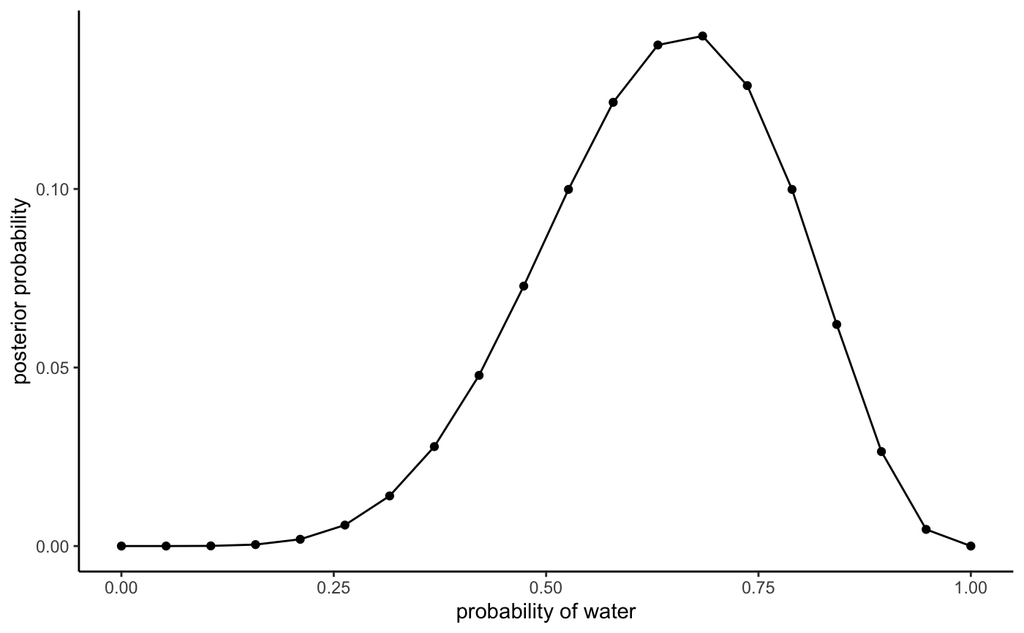

```r
tibble(p_grid, posterior) %>%
  ggplot(aes(p_grid, posterior)) +
  geom_line() +
  geom_point() +
  labs(x = "probability of water",
       y = "posterior probability") +
  theme_classic()
```

But different priors lead to different results.

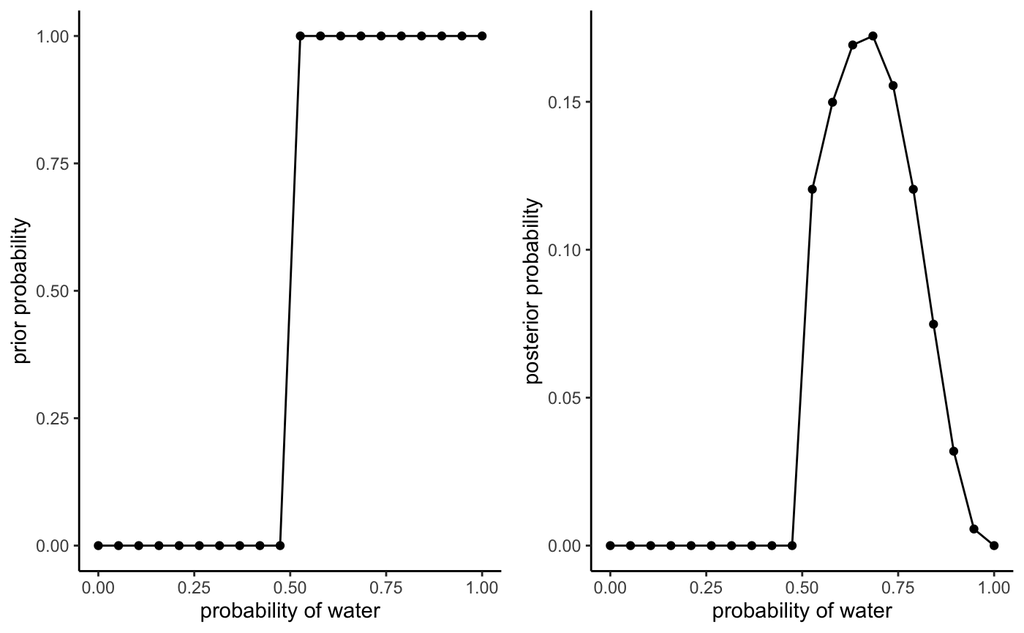

```r
calc_post <- function(prior) {
  lik * prior / sum(lik * prior)
}
plot_prior <- function(prior) {
  tibble(p_grid, prior) %>%
    ggplot(aes(p_grid, prior))  +
    geom_line() +
    geom_point() +
    labs(x = "probability of water",
         y = "prior probability") +
    theme_classic()
}
plot_post <- function(post) {
  tibble(p_grid, post) %>%
    ggplot(aes(p_grid, post)) +
    geom_line() +
    geom_point() +
    labs(x = "probability of water",
         y = "posterior probability") +
    theme_classic()
}
plot_both <- function(prior, post) {
  plot_grid(plot_prior(prior), plot_post(post), nrow = 1)
}

# A step prior
prior_step <- ifelse(p_grid < 0.5, 0, 1)
post_step <- calc_post(prior_step)
plot_both(prior_step, post_step)
```

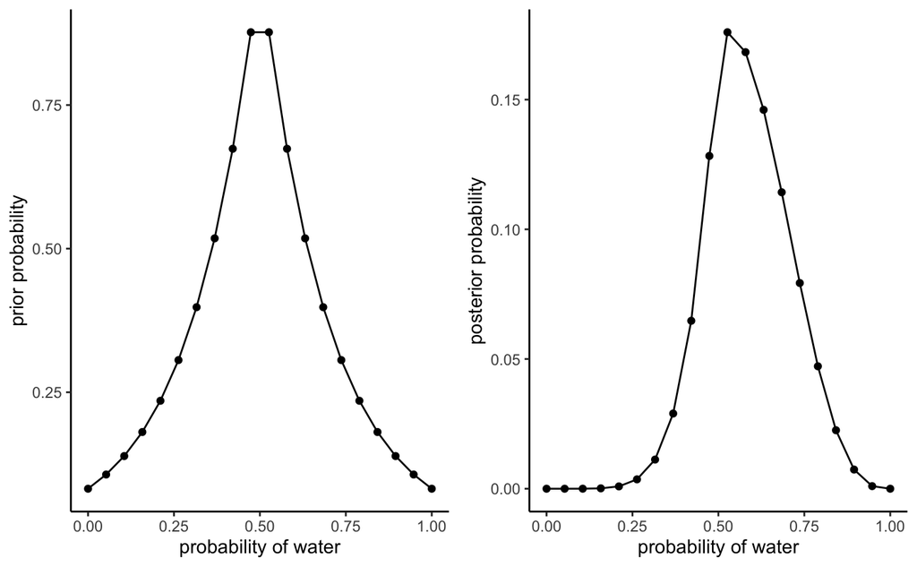

```r
# A pointy prior
prior_pointy <- exp(-5 * abs(p_grid - 0.5))
post_pointy <- calc_post(prior_pointy)
plot_both(prior_pointy, post_pointy)
```

### Quadratic approximation

Often the peak of the posterior will be close to normal, so the most important part of the posterior can be approximated as a Gaussian. The log of a Gaussian is a parabola, which is quadratic. Hence, quadratic approximation.

1. Find the posterior mode (**maximum a posteriori**) via optimization
2. Estimate the curvature near the mode

```r
library(rethinking)
globe.qa <- map(
  alist(
    w ~ dbinom(9, p),  # binomial likelihood
    p ~ dunif(0, 1)    # uniform prior
  ),
  data = list(w = 6)
)

# display summary of quadratic approximation
precis(globe.qa)
```

|  | mean | sd | 5.5% | 94.5% |
| --- | --- | --- | --- | --- |
| p | 0.67 | 0.16 | 0.42 | 0.92 |

The quadratic approximation arrived at a Gaussian with a mean of 0.67 and standard deviation of 0.16. How close is that to accurate? At $n=9$, it’s better on the left side of the mode than the right. It gets better as $n$ increases (Fig. 2.8).

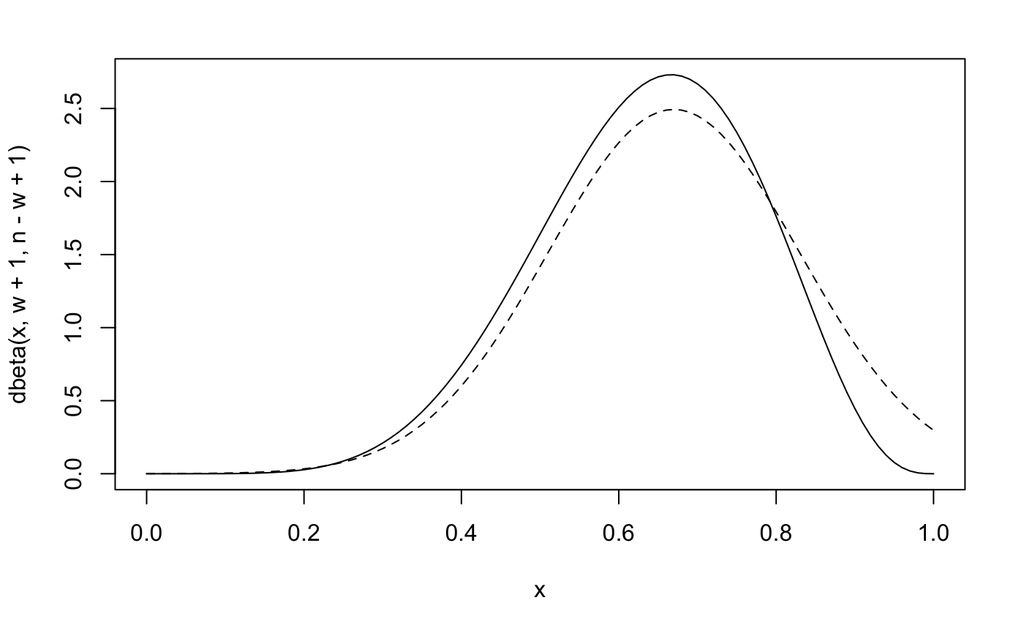

```r
# analytical calculation
w <- 6
n <- 9
curve(dbeta(x, w + 1, n - w + 1), from = 0, to = 1)
curve(dnorm(x, 0.67, 0.16), lty = 2, add = TRUE)
```

### Markov chain Monte Carlo (MCMC)

> The conceptual challenge with MCMC lies in its highly non-obvious strategy. Instead of attempting to compute or approximate the posterior distribution directly, MCMC techniques mereley draw samples from the posterior. You end up with a collection of parameter values, and the frequencies of these values correspond to the posterior plausibilities. You can then build a picture of the posterior from the histogram of these samples.

## Exercises

### Easy

2e1 2

2e2 3

2e3 1, 4

### Medium

2m1

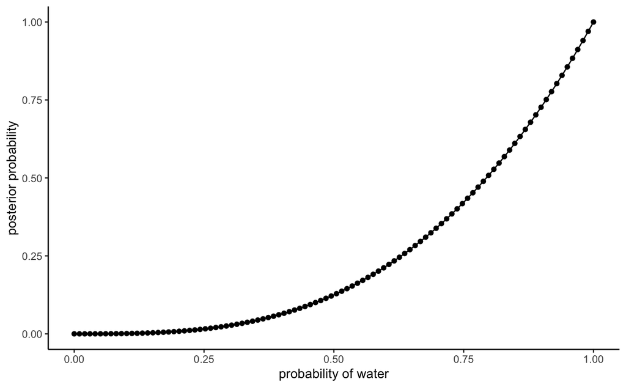

```r
p_grid <- seq(0, 1, length.out = 100)
prior_unif <- rep(1, length(p_grid))
calc_likelihood <- function(w, n, p_grid) {
  dbinom(w, size = n, prob = p_grid)
}
calc_posterior <- function(prior, w, n, p_grid) {
  prior * calc_likelihood(w, n, p_grid)
}
plot_posterior <- function(p_grid, posterior) {
  tibble(p_grid, posterior) %>%
    ggplot(aes(p_grid, posterior)) +
    geom_line() +
    geom_point() +
    labs(x = "probability of water",
         y = "posterior probability") +
    theme_classic()
}

post1 <- calc_posterior(prior_unif, 3, 3, p_grid)
plot_posterior(p_grid, post1)
```

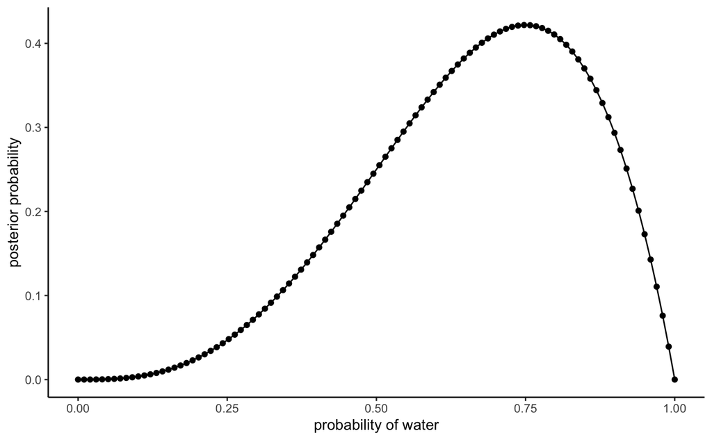

```r
post2 <- calc_posterior(prior_unif, 3, 4, p_grid)
plot_posterior(p_grid, post2)
```

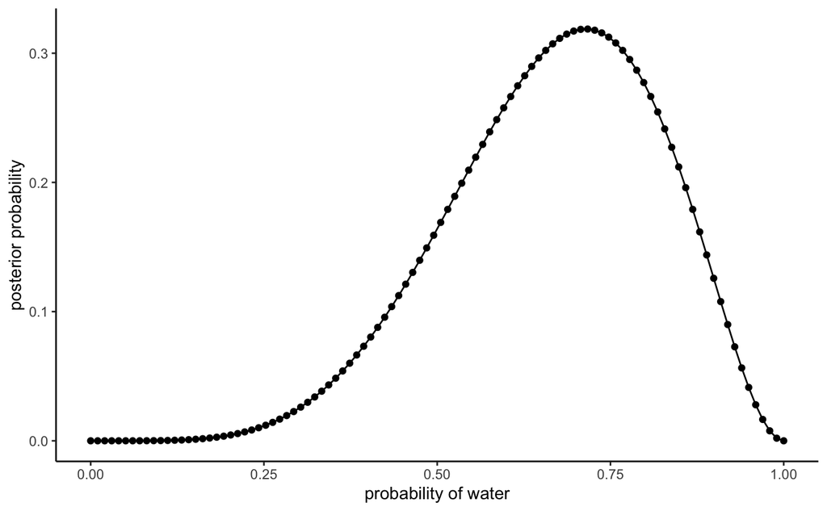

```r
post3 <- calc_posterior(prior_unif, 5, 7, p_grid)
plot_posterior(p_grid, post3)
```

2m2

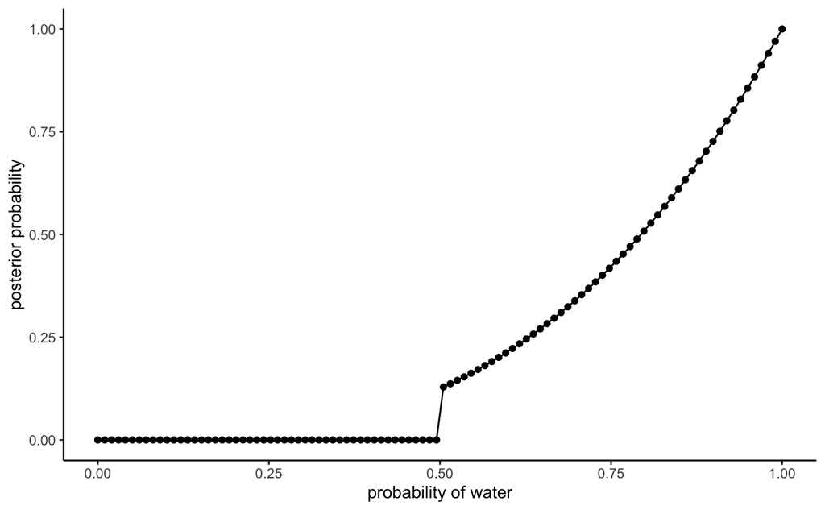

```r
prior_step <- ifelse(p_grid < 0.5, 0, 1)
post1 <- calc_posterior(prior_step, 3, 3, p_grid)
plot_posterior(p_grid, post1)
```

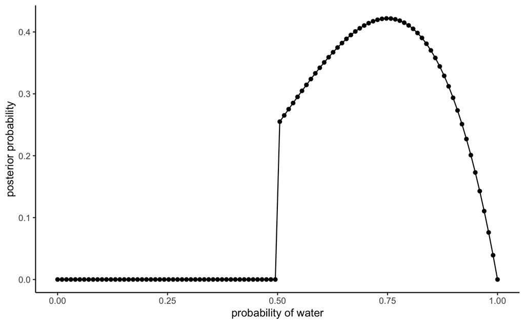

```r
post2 <- calc_posterior(prior_step, 3, 4, p_grid)
plot_posterior(p_grid, post2)
```

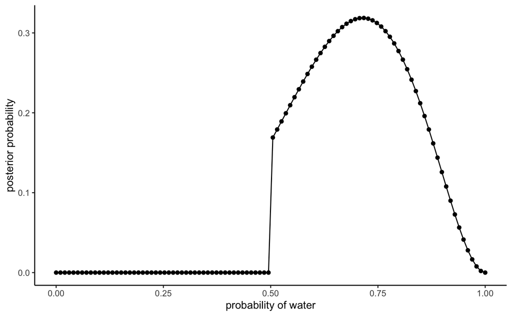

```r
post3 <- calc_posterior(prior_step, 5, 7, p_grid)
plot_posterior(p_grid, post3)
```

2m3

Possible explanations = Earth or Mars

Likelihood: $Pr(L|E) = 0.3$, $Pr(L|M) = 1.0$

Prior plausibility is uniform

$$Pr(L) = \int{Pr(L|p) Pr(p) dp} \\
Pr(L) = Pr(L|E) Pr(E) + Pr(L|M) Pr(M) \\
Pr(L) = 0.3 \times 0.5 + 1.0 \times 0.5 \\
Pr(L) = 0.65$$

$$Pr(E|L) = \frac{Pr(L|E) Pr(E)}{Pr(L)} \\
Pr(E|L) = \frac{0.3 \times 0.5}{0.65} \\
Pr(E|L) = 0.23$$

2m4

| p | ways | plausibility |
| --- | --- | --- |
| ww | 0 | 0 |
| bw | 1 | 1/3 |
| bb | 2 | 2/3 |

2m5

| p | ways | plausibility |
| --- | --- | --- |
| ww | 0 | 0 |
| bw | 1 | 1/5 |
| bb | 4 | 4/5 |

2m6

| p | ways | prior | plausibility |
| --- | --- | --- | --- |
| ww | 0 | 3 | 0 |
| bw | 1 | 2 | 2/4 |
| bb | 2 | 1 | 2/4 |

2m7

| p | ways | plausibility |
| --- | --- | --- |
| ww | 0 | 0 |
| bw | 2 | 2/8 |
| bb | 6 | 6/8 |

### Hard

2h1

$$Pr(A) = 0.5, Pr(B) = 0.5, Pr(t|A) = 0.1, Pr(t|B) = 0.2 \\
Pr(t|t) = Pr(t|A) Pr(A|t) + Pr(t|B) Pr(B|t) \\
Pr(A|t) = \frac{Pr(t|A) Pr(A)}{Pr(t)} \\
Pr(t) = \int{Pr(t|p) Pr(p) dp} \\
Pr(t) = Pr(t|A) Pr(A) + Pr(t|B) Pr(B) \\
Pr(t) = 0.1 \times 0.5 + 0.2 \times 0.5 \\
Pr(t) = 0.15 \\
Pr(A|t) = \frac{0.1 \times 0.5}{0.15} \\
Pr(A|t) = 1/3 \\
Pr(B|t) = 2/3 \\
Pr(t|t) = 0.1 \times 1/3 + 0.2 \times 2/3 \\
Pr(t|t) = 0.17$$

2h2

$$Pr(A|t) = \frac{Pr(t|A) Pr(A)}{Pr(t)} \\
Pr(t) = \int{Pr(t|p) Pr(p) dp} \\
Pr(t) = Pr(t|A) Pr(A) + Pr(t|B) Pr(B) \\
Pr(t) = 0.1 \times 0.5 + 0.2 \times 0.5 \\
Pr(t) = 0.15 \\
Pr(A|t) = \frac{0.1 \times 0.5}{0.15} \\
Pr(A|t) = 1/3$$

2h3

$$Pr(A|ts) = \frac{Pr(ts|A) Pr(A)}{Pr(ts)} \\
Pr(ts) = \int{Pr(ts|p) Pr(p) dp} \\
Pr(ts) = Pr(ts|A) Pr(A) + Pr(ts|B) Pr(B) \\
Pr(ts) = 0.1 \times 0.9 \times 0.5 + 0.2 \times 0.8 \times 0.5 \\
Pr(ts) = 0.125 \\
Pr(A|ts) = \frac{0.1 \times 0.9 \times 0.5}{0.125} \\
Pr(A|ts) = 0.36$$

2h4

Just genetic test:

$$Pr(A_+|A) = 0.8, Pr(B_+|B) = 0.65 \\
Pr(A|A_+) = \frac{Pr(A_+|A) Pr(A)}{Pr(A_+)} \\
Pr(A_+) = \int{Pr(A_+|p) Pr(p) dp} \\
Pr(A_+) = Pr(A_+|A) Pr(A) + Pr(A_+|B) Pr(B) \\
Pr(A_+) = 0.8 \times 0.5 + 0.35 \times 0.5 \\
Pr(A_+) = 0.575 \\
Pr(A|A_+) = \frac{0.8 \times 0.5}{0.575} \\
Pr(A|A_+) = 0.70$$

Genetic test *and* births:

$$\textrm{From genetic test: } Pr(A) = 0.7, Pr(B) = 0.3 \\
Pr(A|t) = \frac{Pr(t|A) Pr(A)}{Pr(t)} \\
Pr(t) = \int{Pr(t|p) Pr(p) dp} \\
Pr(t) = Pr(t|A) Pr(A) + Pr(t|B) Pr(B) \\
Pr(t) = 0.1 \times 0.7 + 0.2 \times 0.3 \\
Pr(t) = 0.13 \\
Pr(A|t) = \frac{0.1 \times 0.7}{0.13} \\
Pr(A|t) = 0.54$$